# Working with Data in the Tidyverse

2020-08-23

In this course, you’ll learn to work with data using tools from the **tidyverse in R**. By data, we mean your own data, other people’s data, messy data, big data, small data - any data with rows and columns that comes your way! By work, we mean doing most of the things that sound hard to do with R, and that need to happen before you can analyze or visualize your data. But work doesn’t mean that it is not fun - you will see why so many people love working in the tidyverse as you learn how to explore, tame, tidy, and transform your data. Throughout this course, you’ll work with data from a popular television baking competition called *"The Great British Bake Off.*"

# Explore your data

## Read a CSV file

In this exercise, you’ll use `read_csv()` function. Remember to use `?read_csv` to read more about arguments like skip and how to use them.

The data you’ll work with is from “The Great British Bake-Off.” The file `"bakeoff.csv"` contains data for each episode of the show, organized by series and baker.

```r
library('readr')
url <- 'https://assets.datacamp.com/production/repositories/1613/datasets/53cf6583aa659942b787897319a1ac053cbcfa5a/bakeoff.csv'
bakeoff <- read_csv(url)
head(bakeoff)
```

```
# A tibble: 6 x 10
  series episode baker signature technical showstopper result uk_airdate
   <dbl>   <dbl> <chr> <chr>         <dbl> <chr>       <chr>  <date>
1      1       1 Anne… "Light J…         2 "Chocolate… IN     2010-08-17
2      1       1 David "Chocola…         3 "Black For… IN     2010-08-17
3      1       1 Edd   "Caramel…         1  <NA>       IN     2010-08-17
4      1       1 Jasm… "Fresh M…        NA  <NA>       IN     2010-08-17
5      1       1 Jona… "Carrot …         9 "Three-lay… IN     2010-08-17
6      1       1 Loui… "Carrot …        NA "Never Fai… IN     2010-08-17
# … with 2 more variables: us_season <dbl>, us_airdate <date>
```

## Assign missing values

The `read_csv()` function also has an `na` argument, which allows you to specify value(s) that represent missing values in your data. The default values for the `na` argument are `c("", "NA")`, so both are recoded as missing `(NA)` in R. When you read in data, you can add additional values like the string `"UNKNOWN"` to a vector of missing values using the `c()` function to combine multiple values into a single vector.

The `is.na()` function is also helpful for identifying rows with missing values for a variable.

```r
# Load dplyr
library('dplyr')

# Filter rows where showstopper is NA
bakeoff %>%
filter(is.na(showstopper))
```

```
# A tibble: 21 x 10
   series episode baker signature technical showstopper result uk_airdate
    <dbl>   <dbl> <chr> <chr>         <dbl> <chr>       <chr>  <date>
 1      1       1 Edd   "Caramel…         1 <NA>        IN     2010-08-17
 2      1       1 Jasm… "Fresh M…        NA <NA>        IN     2010-08-17
 3      1       6 Mira… "Lemon C…        NA <NA>        RUNNE… 2010-09-21
 4      2       1 Ian   "Apple a…        10 <NA>        IN     2011-08-16
 5      2       1 Jason "Lemon M…         6 <NA>        IN     2011-08-16
 6      2       1 Urva… "Cherry …         7 <NA>        IN     2011-08-16
 7      2       1 Yasm… "Cardamo…         5 <NA>        IN     2011-08-16
 8      2       1 Holly "Cherry …         1 <NA>        SB     2011-08-16
 9      2       2 Ben   "Chorizo…         1 <NA>        IN     2011-08-23
10      2       2 Ian   "Stilton…         2 <NA>        IN     2011-08-23
# … with 11 more rows, and 2 more variables: us_season <dbl>, us_airdate <date>
```

## Know your data

## Arrange and glimpse

You can combine `glimpse()` with other functions in a sequence using the pipe `(%>%)` operator. For example, you can use other `dplyr` functions like `arrange` first, then use `glimpse` by adding a line after the final pipe `(%>%)`.

```r
bakeoff %>%
  arrange(us_airdate) %>%
  glimpse()
```

```
Rows: 549
Columns: 10
$ series      <dbl> 4, 4, 4, 4, 4, 4, 4, 4, 4, 4, 4, 4, 4, 4, 4, 4, 4, 4, 4, …
$ episode     <dbl> 1, 1, 1, 1, 1, 1, 1, 1, 1, 1, 1, 1, 1, 2, 2, 2, 2, 2, 2, …
$ baker       <chr> "Ali", "Beca", "Christine", "Deborah", "Frances", "Glenn"…
$ signature   <chr> "Rose and Pistachio Cake", "Grapefruit Sandwich Cake", "S…
$ technical   <dbl> 11, 8, 3, 9, 7, 4, 6, 10, 2, 5, 12, 13, 1, 9, 11, 4, 8, 2…
$ showstopper <chr> "Chocolate, Raspberry and Passion Fruit Engagement Cake",…
$ result      <chr> "IN", "IN", "IN", "IN", "IN", "IN", "IN", "IN", "IN", "IN…
$ uk_airdate  <date> 2013-08-20, 2013-08-20, 2013-08-20, 2013-08-20, 2013-08-…
$ us_season   <dbl> 1, 1, 1, 1, 1, 1, 1, 1, 1, 1, 1, 1, 1, 1, 1, 1, 1, 1, 1, …
$ us_airdate  <date> 2014-12-28, 2014-12-28, 2014-12-28, 2014-12-28, 2014-12-…
```

The first episode of the first US season aired on December 28, 2014.

## Summarize your data

You can combine `skim()` with other functions in a sequence using the pipe `(%>%)` operator. For example, you could use other `dplyr` functions like `group_by` first, then use `skim()` by adding a line after the final pipe.

```r
# Load skimr
library('skimr')

# Edit to filter, group by, and skim
bakeoff %>%
  filter(!is.na(us_season)) %>%
  group_by(us_season) %>%
  skim()
```

Data summary

| Name | Piped data |
| --- | --- |
| Number of rows | 302 |
| Number of columns | 10 |
| _______________________ |  |
| Column type frequency: |  |
| character | 4 |
| Date | 2 |
| numeric | 3 |
| ________________________ |  |
| Group variables | us_season |

**Variable type: character**

| skim_variable | us_season | n_missing | complete_rate | min | max | empty | n_unique | whitespace |
| --- | --- | --- | --- | --- | --- | --- | --- | --- |
| baker | 1 | 0 | 1.00 | 3 | 9 | 0 | 13 | 0 |
| baker | 2 | 0 | 1.00 | 4 | 7 | 0 | 12 | 0 |
| baker | 3 | 0 | 1.00 | 3 | 6 | 0 | 12 | 0 |
| baker | 4 | 0 | 1.00 | 3 | 9 | 0 | 12 | 0 |
| signature | 1 | 0 | 1.00 | 10 | 125 | 0 | 78 | 0 |
| signature | 2 | 1 | 0.99 | 15 | 107 | 0 | 73 | 0 |
| signature | 3 | 0 | 1.00 | 12 | 64 | 0 | 74 | 0 |
| signature | 4 | 0 | 1.00 | 12 | 93 | 0 | 75 | 0 |
| showstopper | 1 | 0 | 1.00 | 5 | 126 | 0 | 78 | 0 |
| showstopper | 2 | 1 | 0.99 | 8 | 82 | 0 | 73 | 0 |
| showstopper | 3 | 0 | 1.00 | 10 | 70 | 0 | 73 | 0 |
| showstopper | 4 | 0 | 1.00 | 5 | 86 | 0 | 74 | 0 |
| result | 1 | 0 | 1.00 | 2 | 9 | 0 | 5 | 0 |
| result | 2 | 0 | 1.00 | 2 | 9 | 0 | 6 | 0 |
| result | 3 | 0 | 1.00 | 2 | 9 | 0 | 5 | 0 |
| result | 4 | 0 | 1.00 | 2 | 9 | 0 | 5 | 0 |

**Variable type: Date**

| skim_variable | us_season | n_missing | complete_rate | min | max | median | n_unique |
| --- | --- | --- | --- | --- | --- | --- | --- |
| uk_airdate | 1 | 0 | 1 | 2013-08-20 | 2013-10-22 | 2013-09-10 | 10 |
| uk_airdate | 2 | 0 | 1 | 2014-08-06 | 2014-10-08 | 2014-08-27 | 10 |
| uk_airdate | 3 | 0 | 1 | 2015-08-05 | 2015-10-07 | 2015-08-26 | 10 |
| uk_airdate | 4 | 0 | 1 | 2016-08-24 | 2016-10-26 | 2016-09-14 | 10 |
| us_airdate | 1 | 0 | 1 | 2014-12-28 | 2015-03-01 | 2015-01-18 | 10 |
| us_airdate | 2 | 0 | 1 | 2015-09-06 | 2015-11-08 | 2015-09-27 | 10 |
| us_airdate | 3 | 0 | 1 | 2016-07-01 | 2016-08-12 | 2016-07-15 | 7 |
| us_airdate | 4 | 0 | 1 | 2017-06-16 | 2017-08-04 | 2017-06-30 | 8 |

**Variable type: numeric**

| skim_variable | us_season | n_missing | complete_rate | mean | sd | p0 | p25 | p50 | p75 | p100 | hist |
| --- | --- | --- | --- | --- | --- | --- | --- | --- | --- | --- | --- |
| series | 1 | 0 | 1.00 | 4.00 | 0.00 | 4 | 4.00 | 4.0 | 4 | 4 | ▁▁▇▁▁ |
| series | 2 | 0 | 1.00 | 5.00 | 0.00 | 5 | 5.00 | 5.0 | 5 | 5 | ▁▁▇▁▁ |
| series | 3 | 0 | 1.00 | 6.00 | 0.00 | 6 | 6.00 | 6.0 | 6 | 6 | ▁▁▇▁▁ |
| series | 4 | 0 | 1.00 | 7.00 | 0.00 | 7 | 7.00 | 7.0 | 7 | 7 | ▁▁▇▁▁ |
| episode | 1 | 0 | 1.00 | 4.31 | 2.66 | 1 | 2.00 | 4.0 | 6 | 10 | ▇▆▅▃▂ |
| episode | 2 | 0 | 1.00 | 4.38 | 2.68 | 1 | 2.00 | 4.0 | 6 | 10 | ▇▆▅▃▂ |
| episode | 3 | 0 | 1.00 | 4.40 | 2.67 | 1 | 2.00 | 4.0 | 6 | 10 | ▇▆▅▃▂ |
| episode | 4 | 0 | 1.00 | 4.40 | 2.67 | 1 | 2.00 | 4.0 | 6 | 10 | ▇▆▅▃▂ |
| technical | 1 | 0 | 1.00 | 5.08 | 3.19 | 1 | 2.25 | 4.5 | 7 | 13 | ▇▅▅▂▂ |
| technical | 2 | 1 | 0.99 | 4.73 | 2.93 | 1 | 2.00 | 4.0 | 7 | 12 | ▇▅▃▂▂ |
| technical | 3 | 0 | 1.00 | 4.80 | 2.92 | 1 | 2.00 | 4.0 | 7 | 12 | ▇▅▃▂▂ |
| technical | 4 | 0 | 1.00 | 4.80 | 2.92 | 1 | 2.00 | 4.0 | 7 | 12 | ▇▅▃▂▂ |

Nice piping & skimming! Producing quick grouped summaries with the skim function is a real time (and sanity) saver.

## Know your variable types

How many variables of each type do we have in the `bakeoff` data? You may use any of the data science tools we’ve learned for getting to know your data. You may also want to try piping a skimmed object to `summary()`, also from the `skimr` package

```r
bakeoff %>%
  skim() %>%  # no argument needed here
  summary()   # no argument needed here
```

Data summary

| Name | Piped data |
| --- | --- |
| Number of rows | 549 |
| Number of columns | 10 |
| _______________________ |  |
| Column type frequency: |  |
| character | 4 |
| Date | 2 |
| numeric | 4 |
| ________________________ |  |
| Group variables | None |

## Count with your data

## Distinct and count

In every episode of *“The Great British Bake-Off”*, bakers complete 3 challenges and the show’s judges award the title *“Star Baker”* to the baker who excelled in that week’s challenges (with the exception of the finale). Each baker’s result for every episode is stored in `result` is a character variable, and the value `"SB"` stands for star baker.

```r
# Count rows for each result
bakeoff %>%
  distinct(result)
```

```
# A tibble: 6 x 1
  result
  <chr>
1 IN
2 OUT
3 RUNNER UP
4 WINNER
5 SB
6 LEFT
```

```r
# Count whether or not star baker
bakeoff %>%
  count(result)
```

```
# A tibble: 6 x 2
  result        n
  <chr>     <int>
1 IN          393
2 LEFT          1
3 OUT          70
4 RUNNER UP    16
5 SB           61
6 WINNER        8
```

Adapt your code to count by a logical condition instead: if the result is equal to `"SB"`

```r
# Count whether or not star baker
bakeoff %>%
  count(result=='SB')
```

```
# A tibble: 2 x 2
  `result == "SB"`     n
  <lgl>            <int>
1 FALSE              488
2 TRUE                61
```

## Count episodes

Recall that `bakeoff` includes each baker’s result for every episode. Let’s practice counting the number of episodes per series.

```r
# Add second count by series
bakeoff %>%
  count(series, episode)
```

```
# A tibble: 74 x 3
   series episode     n
    <dbl>   <dbl> <int>
 1      1       1    10
 2      1       2     8
 3      1       3     6
 4      1       4     5
 5      1       5     4
 6      1       6     3
 7      2       1    12
 8      2       2    11
 9      2       3    10
10      2       4     8
# … with 64 more rows
```

Remark that this is equivalent to write

```r
bakeoff %>%
  group_by(series, episode) %>%
  summarise(n())
```

```
# A tibble: 74 x 3
# Groups:   series [8]
   series episode `n()`
    <dbl>   <dbl> <int>
 1      1       1    10
 2      1       2     8
 3      1       3     6
 4      1       4     5
 5      1       5     4
 6      1       6     3
 7      2       1    12
 8      2       2    11
 9      2       3    10
10      2       4     8
# … with 64 more rows
```

```r
# Add second count by series
bakeoff %>%
  count(series, episode) %>%
  count(series)
```

```
# A tibble: 8 x 2
  series     n
   <dbl> <int>
1      1    36
2      2    60
3      3    76
4      4    78
5      5    74
6      6    75
7      7    75
8      8    75
```

Remark that this is equivalent to write

```r
bakeoff %>%
  group_by(series) %>%
  summarise(n()) %>%
  ungroup()
```

```
# A tibble: 8 x 2
  series `n()`
   <dbl> <int>
1      1    36
2      2    60
3      3    76
4      4    78
5      5    74
6      6    75
7      7    75
8      8    75
```

## Count bakers

Now, using the same data, you’ll practice that again, focusing on counting bakers.

```r
# Count the number of rows by series and baker
bakers_by_series <- bakeoff %>%
  count(series, baker)

# Print to view
bakers_by_series
```

```
# A tibble: 95 x 3
   series baker         n
    <dbl> <chr>     <int>
 1      1 Annetha       2
 2      1 David         4
 3      1 Edd           6
 4      1 Jasminder     5
 5      1 Jonathan      3
 6      1 Lea           1
 7      1 Louise        2
 8      1 Mark          1
 9      1 Miranda       6
10      1 Ruth          6
# … with 85 more rows
```

Add a line to `count` the already counted tibble by series again. Which series had the most bakers? Which had the least?

```r
# Count again by series
bakers_by_series %>%
  count(series, sort=TRUE)
```

```
# A tibble: 8 x 2
  series     n
   <dbl> <int>
1      4    78
2      3    76
3      6    75
4      7    75
5      8    75
6      5    74
7      2    60
8      1    36
```

Series 4 had the most bakers.

Now count the same tibble by baker again and use `sort = TRUE`. What’s the most common baker name?

```r
# Count again by baker
bakers_by_series %>%
count(baker, sort=TRUE)
```

```
# A tibble: 86 x 2
   baker       n
   <chr>   <int>
 1 Kate       21
 2 James      15
 3 Ian        13
 4 Tom        11
 5 Andrew     10
 6 Brendan    10
 7 Candice    10
 8 Frances    10
 9 Jane       10
10 John       10
# … with 76 more rows
```

Kate is the most popular name. Kates have appeared in 3 different series of the TV show.

## Plot counts

You can learn a lot about your data by counting, but sometimes you can learn even more by plotting counts. This is especially true when you have lots of things to count! With eight series, 74 episodes, and 95 bakers, a plot can be more helpful than a table of numbers. We’ll use `ggplot2` to visualize the number of bakers across episodes for each series from bakers.

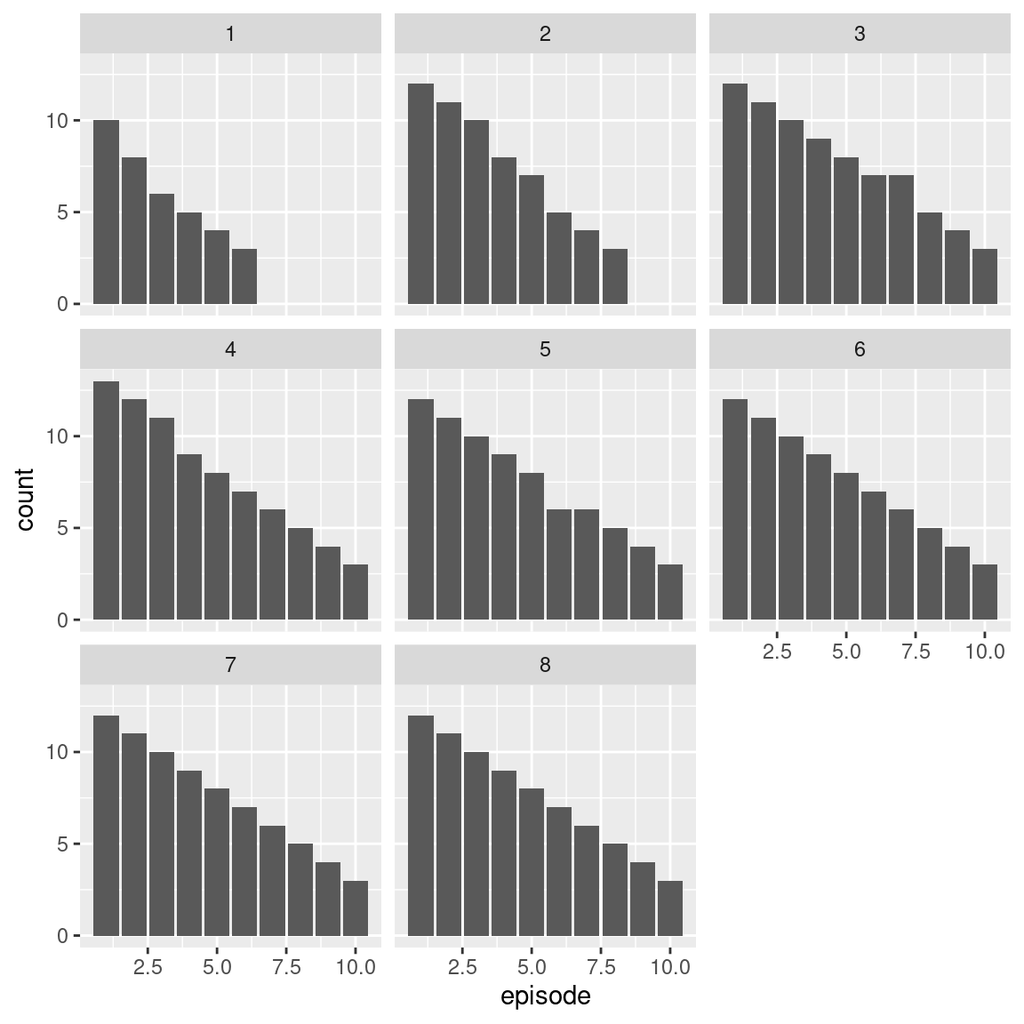

```r
library('ggplot2')

bakeoff %>%
ggplot(aes(x=episode)) +
    geom_bar() +
    facet_wrap(~series)
```

# Tame your data

## Cast column types

## Cast a column to a date

A good workflow for parsing dates using `readr` is to, for example:

- Use `parse_date("2012-14-08", format = "%Y-%d-%m")` first, then
- Use `col_date(format = "%Y-%d-%m")` within `cols()` as the `col_types` argument of `read_csv()`.

In `"desserts.csv"`, the variable `uk_airdate` is formatted like `"17 August 2010"`. Let’s parse, then cast this variable!

```r
# Find format to parse uk_airdate
parse_date("17 August 2010", format = "%d %B %Y")

# Edit to cast uk_airdate
desserts <- read_csv("desserts.csv", col_types = cols(uk_airdate = col_date(format = "%d %B %Y")))

# Arrange by descending uk_airdate
desserts %>% arrange(desc(uk_airdate))
```

```r
# A tibble: 549 x 16
   series episode baker technical result uk_airdate us_season us_airdate
    <dbl>   <dbl> <chr> <chr>     <chr>  <date>         <dbl> <date>
 1      8      10 Kate  3rd       RUNNE~ 2017-10-31        NA NA
 2      8      10 Stev~ 1st       RUNNE~ 2017-10-31        NA NA
 3      8      10 Soph~ 2nd       WINNER 2017-10-31        NA NA
 4      8       9 Kate  4th       IN     2017-10-24        NA NA
 5      8       9 Stev~ 3rd       IN     2017-10-24        NA NA
 6      8       9 Stac~ 2nd       OUT    2017-10-24        NA NA
 7      8       9 Soph~ 1st       SB     2017-10-24        NA NA
 8      8       8 Kate  2nd       IN     2017-10-17        NA NA
 9      8       8 Soph~ 4th       IN     2017-10-17        NA NA
10      8       8 Stev~ 1st       IN     2017-10-17        NA NA
# ... with 539 more rows, and 8 more variables: showstopper_chocolate <chr>,
#   showstopper_dessert <chr>, showstopper_fruit <chr>, showstopper_nut <chr>,
#   signature_chocolate <chr>, signature_dessert <chr>, signature_fruit <chr>,
#   signature_nut <chr>
```

## Cast a column to a number

A good workflow for parsing columns using `readr`:

Use `parse_number()` to practice, then Use `col_number()` to cast.

But sometimes you’ll need to start with casting, then diagnose parsing problems using a new readr function called `problems()`. Using `problems()` on a result of `read_csv()` will show you the rows and columns where parsing error occurred, what the parser expected to find (for example, a number), and the actual value that caused the parsing error.

# Tidy your data

# Transform your data